# Cross-cancer deviation

Pan-cancer aging project

October 24, 2026

```r
suppressPackageStartupMessages({
  library(dplyr)
  library(tibble)
  library(ggplot2)
  library(grid)
  library(here)
  library(tidytext)
  library(ggtext)
  library(stringr)
  library(purrr)
  library(tidyr)
  library(scales)
  library(survival)
  library(knitr)
  library(cowplot)
})
```

## Highlight set + global options

```r
feature_set <- "PC"
base_dir    <- "results/derived/GTEx"

highlight_tbl <- tibble(
  tcga_project = c("BRCA", "LUAD", "LUSC", "GBM", "LGG", "COAD"),
  gtex_project = c("BREAST", "LUNG", "LUNG", "BRAIN", "BRAIN", "COLON")
)

# Keep this explicit so the manuscript figure respects the pre-specified emphasis set.
highlight_order <- highlight_tbl$tcga_project
```

## Helpers

```r
clean_pathway_label <- function(x) {
  dplyr::recode(
    x,
    "Reactive Oxygen Species Pathway" = "ROS Pathway",
    "Il2 Stat5 Signaling" = "IL2/STAT5 Signaling",
    "Il6 Jak Stat3 Signaling" = "IL6/JAK/STAT3",
    "Tnfa Signaling Via Nfkb" = "TNF\u03b1 \u2192 NF\u03baB",
    "Pi3k Akt Mtor Signaling" = "PI3K/AKT/MTOR Signaling",
    "Mitotic Spindle" = "Mitotic Spindle",
    "Epithelial Mesenchymal Transition" = "EMT",
    "Wnt Beta Catenin Signaling" = "WNT/\u03b2-Catenin",
    "Interferon Alpha Response" = "IFN\u03b1 Response",
    "Xenobiotic Metabolism" = "Xenobiotic Metab.",
    "Unfolded Protein Response" = "UPR",
    "Inflammatory Response"     = "Inflammatory Resp.",
    "Fatty Acid Metabolism" = "Fatty Acid Metab.",
    .default = x
  )
}

load_fig4_objects <- function(tcga_project,
                              gtex_project,
                              feature_set = "PC",
                              base_dir = "results/derived/GTEx") {

  analysis_id <- paste0(tcga_project, "__", gtex_project)
  analysis_dir <- file.path(here::here(base_dir), analysis_id)
  suffix <- paste0("-", feature_set)

  surv_path <- file.path(analysis_dir,
                         paste0("survival_deviation_results", suffix, ".rds"))

  list(
    analysis_id = analysis_id,
    tcga_project = tcga_project,
    gtex_project = gtex_project,
    shap = readRDS(file.path(analysis_dir, paste0("clockshap_objects", suffix, ".rds"))),
    survival = if (file.exists(surv_path)) readRDS(surv_path) else NULL
  )
}
```

## Load saved objects

```r
fig4_objs <- purrr::pmap(
  highlight_tbl,
  ~ load_fig4_objects(..1, ..2, feature_set = feature_set, base_dir = base_dir)
)

names(fig4_objs) <- highlight_tbl$tcga_project

stopifnot(all(highlight_order %in% names(fig4_objs)))
```

## Cross-cancer mean deviation ordering

```r
fig4_mean_shap_tbl <- purrr::imap_dfr(
  fig4_objs,
  function(obj, cancer) {
    phi <- obj$shap$pt$phi
    stopifnot(!is.null(phi), is.matrix(phi) || is.data.frame(phi))
    phi <- as.matrix(phi)

    tibble(
      cancertype = cancer,
      pathway = colnames(phi),
      mean_phi = colMeans(phi, na.rm = TRUE)
    )
  }
) %>%
  mutate(pathway = clean_pathway_label(pathway))

fig4A_deviation_tbl <- fig4_mean_shap_tbl %>%
  group_by(cancertype) %>%
  summarise(
    mean_deviation = sum(mean_phi, na.rm = TRUE),
    .groups = "drop"
  ) %>%
  arrange(desc(mean_deviation)) %>%
  mutate(
    cancertype = factor(cancertype, levels = cancertype),
    direction = if_else(mean_deviation >= 0, "Older", "Younger")
  )

knitr::kable(fig4A_deviation_tbl, digits = 2,
             caption = "Mean age-matched deviation per cancer (values labelled on the bars).")
```

Mean age-matched deviation per cancer (values labelled on the bars).

| cancertype | mean_deviation | direction |
| --- | --- | --- |
| LGG | -0.07 | Younger |
| COAD | -9.40 | Younger |
| LUAD | -14.58 | Younger |
| GBM | -16.26 | Younger |
| LUSC | -18.84 | Younger |
| BRCA | -22.94 | Younger |

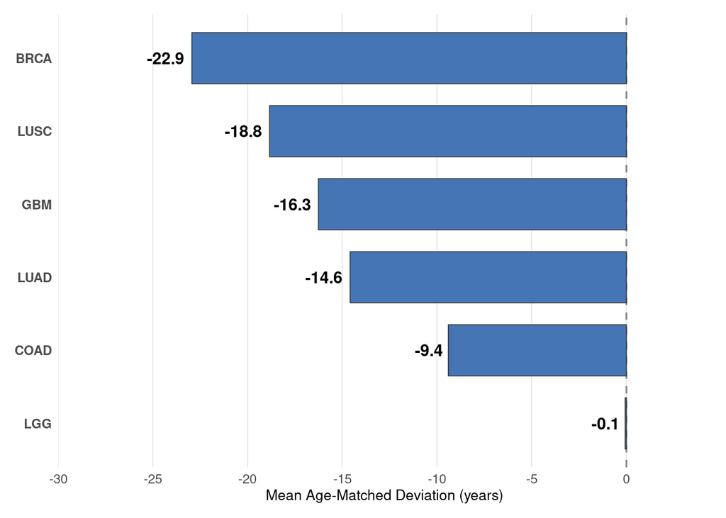

```r
p_fig4A <- ggplot(
  fig4A_deviation_tbl,
  aes(x = mean_deviation, y = cancertype, fill = direction)
) +
  geom_vline(xintercept = 0, linetype = "dashed", colour = "grey55", linewidth = 0.6) +
  geom_col(width = 0.7, colour = "grey20", linewidth = 0.3) +
  geom_text(
    aes(label = sprintf("%+.1f", mean_deviation),
        hjust = if_else(mean_deviation >= 0, -0.1, 1.2)),
    fontface = "bold",
    size = 4
  ) +
  scale_fill_manual(values = c("Older" = "#d73027", "Younger" = "#4575b4"),
                    guide = "none") +
  scale_x_continuous(
  limits = c(-30, NA),
  expand = expansion(mult = c(0, 0.15)),
  breaks = scales::pretty_breaks(n = 6)
  ) +
  labs(
    x = "Mean Age-Matched Deviation (years)",
    y = NULL
  ) +
  theme_minimal(base_size = 10) +
  theme(
    panel.grid.minor = element_blank(),
    panel.grid.major.y = element_blank(),
    axis.text.y = element_text(size = 9, face = "bold"),
    axis.text.x = element_text(size = 9),
    axis.title = element_text(size = 10),
    plot.margin = margin(10, 10, 10, 10)
  )

p_fig4A
```

```r
out_dir <- here::here("results", "figures", "figure_crosscancer")
dir.create(out_dir, recursive = TRUE, showWarnings = FALSE)

out_file <- file.path(out_dir, "CrossCancer_Mean_Deviation.pdf")

ggsave(
  filename = out_file,
  plot = p_fig4A,
  width = 3.75,
  height = 2.5,
  units = "in"
)

message("Saved: ", out_file)
```

## Pan-cancer Cox forest plot (OS, age-adjusted)

This panel shows the OS Cox hazard ratio per +1 year of GTEx-anchored Deviation, age-adjusted, across all 6 emphasis cancers. Loads `survival_deviation_results-PC.rds` per cancer. Sorted by HR with the smallest HR at the top. Blue points indicate HR < 1 (youthful deviation associates with increased risk); red points indicate HR > 1 (less-youthful deviation associates with increased risk). Filled circles indicate p < 0.05; open circles indicate p >= 0.05.

```r
fig4B_tbl <- purrr::imap_dfr(fig4_objs, function(obj, cancer) {
  if (is.null(obj$survival) || is.null(obj$survival$surv_res_os)) {
    warning(sprintf("No surv_res_os for %s", cancer))
    return(NULL)
  }
  obj$survival$surv_res_os %>%
    mutate(cancertype = cancer)
}) %>%
  mutate(
    HR     = HR_per1yr_dev,
    sig    = ifelse(p_value < 0.05, "p < 0.05", "p \u2265 0.05"),
    hr_dir = factor(
      ifelse(HR < 1,
             "Youthful deviation, increased risk",
             "Less-youthful deviation, increased risk"),
      levels = c("Youthful deviation, increased risk",
                 "Less-youthful deviation, increased risk")
    ),
    label  = cancertype
  ) %>%
  arrange(HR) %>%
  mutate(label = factor(label, levels = rev(label)))  # smallest HR at top

knitr::kable(
  fig4B_tbl %>%
    transmute(cancertype, n, events, HR, CI_low, CI_high, p_value, sig),
  digits = 4,
  caption = "Pan-cancer OS Cox HR per +1 year of deviation, age-adjusted."
)
```

Pan-cancer OS Cox HR per +1 year of deviation, age-adjusted.

| cancertype | n | events | HR | CI_low | CI_high | p_value | sig |
| --- | --- | --- | --- | --- | --- | --- | --- |
| LGG | 512 | 125 | 0.9510 | 0.9331 | 0.9693 | 0.0000 | p < 0.05 |
| BRCA | 1116 | 151 | 0.9839 | 0.9691 | 0.9989 | 0.0358 | p < 0.05 |
| LUAD | 520 | 185 | 0.9929 | 0.9752 | 1.0110 | 0.4387 | p ≥ 0.05 |
| GBM | 156 | 124 | 1.0004 | 0.9785 | 1.0229 | 0.9699 | p ≥ 0.05 |
| LUSC | 488 | 210 | 1.0127 | 0.9964 | 1.0292 | 0.1277 | p ≥ 0.05 |
| COAD | 499 | 109 | 1.0389 | 1.0126 | 1.0659 | 0.0035 | p < 0.05 |

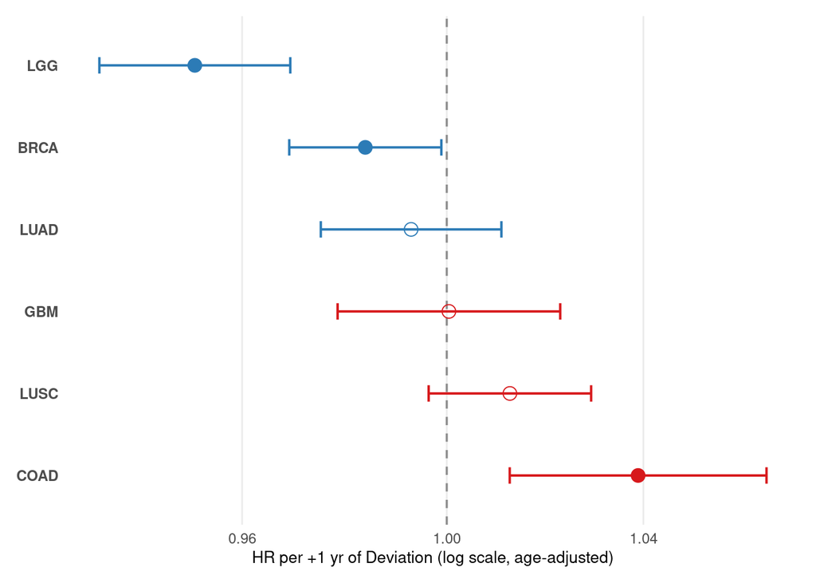

```r
hr_pal <- c(
  "Youthful deviation, increased risk"      = "#2c7bb6",
  "Less-youthful deviation, increased risk" = "#d7191c"
)

p_fig4B <- ggplot(fig4B_tbl, aes(x = HR, y = label, colour = hr_dir)) +
  geom_vline(xintercept = 1, linetype = "dashed", colour = "grey55", linewidth = 0.6) +
  geom_errorbarh(aes(xmin = CI_low, xmax = CI_high),
                 height = 0.20, linewidth = 0.7) +
  geom_point(aes(shape = sig), size = 3.6) +
  scale_x_log10() +
  scale_shape_manual(values = c("p < 0.05" = 19, "p \u2265 0.05" = 1),
                     name = NULL) +
  scale_colour_manual(values = hr_pal, name = NULL) +
  labs(
    x = "HR per +1 yr of Deviation (log scale, age-adjusted)",
    y = NULL
  ) +
  theme_minimal(base_size = 11) +
  theme(
    panel.grid.minor = element_blank(),
    panel.grid.major.y = element_blank(),
    legend.position    = "none",
    axis.text.y        = element_text(size = 9, face = "bold"),
    axis.text.x        = element_text(size = 9),
    axis.title         = element_text(size = 10),
    plot.margin        = margin(10, 10, 10, 10)
  )

p_fig4B
```

```r
fig4B_legend <- cowplot::get_legend(
  p_fig4B +
    theme(
      legend.position = "bottom",
      legend.box = "vertical",
      legend.margin = margin(0, 0, 0, 0)
    )
)

p_fig4B_nolegend <- p_fig4B +
  theme(legend.position = "none")
```

```r
ggsave(
  filename = file.path(out_dir, "PanCancer_Survival_OS.pdf"),
  plot = p_fig4B_nolegend,
  width = 3.75,
  height = 2.5,
  units = "in"
)

ggsave(
  filename = file.path(out_dir, "PanCancer_Survival_OS_legend.pdf"),
  plot = fig4B_legend,
  width = 4,
  height = 0.7,
  units = "in"
)
```

## Cross-cancer deviation decomposition (waterfalls, all 6 cancers)

This panel summarizes the mean tumor ClockSHAP contributions in each of the 6 emphasis cancers. Bars show the top-N pathway-level contributors to tumor deviation, with the remainder collapsed into Other. The dashed summary row shows the net mean tumor deviation. Cancers are stacked vertically and ordered by total mean deviation (most negative at top, most positive at bottom).

```r
fig4C_top_k <- 4L
fig4C_summary_label <- "Mean Age Deviation"

fig4C_rank_tbl <- fig4_mean_shap_tbl %>%
  group_by(cancertype) %>%
  arrange(desc(abs(mean_phi)), .by_group = TRUE) %>%
  mutate(
    rank = row_number(),
    pathway_group = if_else(rank <= fig4C_top_k, pathway, "Other")
  ) %>%
  group_by(cancertype, pathway_group) %>%
  summarise(contrib = sum(mean_phi, na.rm = TRUE), .groups = "drop")

knitr::kable(fig4C_rank_tbl, digits = 2,
             caption = "Top pathway contributions and remainder per cancer, as drawn in the waterfalls.")
```

Top pathway contributions and remainder per cancer, as drawn in the waterfalls.

| cancertype | pathway_group | contrib |
| --- | --- | --- |
| BRCA | G2m Checkpoint | -7.42 |
| BRCA | Glycolysis | -6.31 |
| BRCA | Myogenesis | -4.77 |
| BRCA | Other | -1.48 |
| BRCA | P53 Pathway | -2.96 |
| COAD | Mtorc1 Signaling | 10.00 |
| COAD | Myc Targets V2 | -11.34 |
| COAD | Myogenesis | -7.16 |
| COAD | Other | -12.18 |
| COAD | P53 Pathway | 11.29 |
| GBM | Angiogenesis | -7.70 |
| GBM | G2m Checkpoint | -14.50 |
| GBM | Myc Targets V1 | -14.49 |
| GBM | Other | 8.97 |
| GBM | P53 Pathway | 11.46 |
| LGG | G2m Checkpoint | -7.53 |
| LGG | Myc Targets V1 | -7.03 |
| LGG | Myc Targets V2 | 5.17 |
| LGG | Other | 3.38 |
| LGG | P53 Pathway | 5.96 |
| LUAD | Angiogenesis | 3.54 |
| LUAD | E2f Targets | -2.63 |
| LUAD | EMT | -3.67 |
| LUAD | G2m Checkpoint | -3.56 |
| LUAD | Other | -8.26 |
| LUSC | Angiogenesis | 3.99 |
| LUSC | E2f Targets | -4.28 |
| LUSC | EMT | -2.60 |
| LUSC | G2m Checkpoint | -6.36 |
| LUSC | Other | -9.59 |

```r
fig4C_segment_tbl <- fig4C_rank_tbl %>%
  group_by(cancertype) %>%
  arrange(pathway_group == "Other", desc(abs(contrib)), .by_group = TRUE) %>%
  mutate(
    ord       = row_number(),
    start     = cumsum(lag(contrib, default = 0)),
    end       = start + contrib,
    direction = if_else(contrib >= 0, "Older", "Younger"),
    n_path    = sum(pathway_group != "Other"),
    y_rank    = if_else(pathway_group == "Other", 0, n_path - ord + 1)
  ) %>%
  select(-n_path) %>%
  ungroup()

fig4C_total_tbl <- fig4C_segment_tbl %>%
  group_by(cancertype) %>%
  summarise(total_dev = sum(contrib), .groups = "drop") %>%
  transmute(
    cancertype,
    pathway_group = fig4C_summary_label,
    contrib   = total_dev,
    start     = 0,
    end       = total_dev,
    direction = if_else(total_dev >= 0, "Older", "Younger"),
    y_rank    = -1
  )

# Order cancers by total mean deviation: most negative at top of stack, most positive at bottom.
fig4C_cancer_order <- fig4C_total_tbl %>%
  arrange(contrib) %>%
  pull(cancertype)

fig4C_plot_tbl <- bind_rows(fig4C_segment_tbl, fig4C_total_tbl) %>%
  mutate(cancertype = factor(cancertype, levels = fig4C_cancer_order)) %>%
  arrange(cancertype, desc(y_rank)) %>%
  group_by(cancertype) %>%
  mutate(pathway_within = reorder_within(pathway_group, y_rank, cancertype)) %>%
  ungroup()

fig4C_x_min <- min(c(fig4C_plot_tbl$start, fig4C_plot_tbl$end), na.rm = TRUE)
fig4C_x_max <- max(c(fig4C_plot_tbl$start, fig4C_plot_tbl$end), na.rm = TRUE)
fig4C_pad_left  <- 0.30 * (fig4C_x_max - fig4C_x_min)
fig4C_pad_right <- 0.06 * (fig4C_x_max - fig4C_x_min)
```

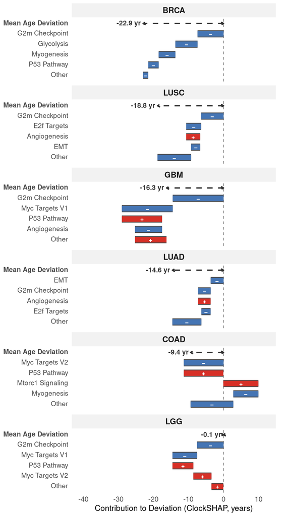

```r
fig4C_summary_signs <- fig4C_plot_tbl %>%
  filter(pathway_group == fig4C_summary_label) %>%
  arrange(cancertype) %>%
  pull(contrib)

p_fig4C <- ggplot(fig4C_plot_tbl, aes(y = pathway_within)) +
  geom_vline(xintercept = 0, linetype = "dashed", colour = "grey55", linewidth = 0.4) +

  # Pathway segments: coloured fill on top of grey base for separation
  geom_segment(
    data = \(d) d %>% filter(pathway_group != fig4C_summary_label),
    aes(x = start, xend = end, yend = pathway_within),
    linewidth = 4.2, lineend = "butt", colour = "grey30"
  ) +
  geom_segment(
    data = \(d) d %>% filter(pathway_group != fig4C_summary_label),
    aes(x = start, xend = end, yend = pathway_within, colour = direction),
    linewidth = 3.2, lineend = "butt"
  ) +
  geom_text(
    data = \(d) d %>% filter(pathway_group != fig4C_summary_label),
    aes(x = (start + end) / 2,
        label = if_else(contrib >= 0, "+", "\u2212")),
    colour = "white", fontface = "bold", size = 2.7, show.legend = FALSE
  ) +

  # Summary row: dashed double-arrow plus labelled total
  geom_segment(
    data = \(d) d %>% filter(pathway_group == fig4C_summary_label),
    aes(x = start, xend = end, y = pathway_within, yend = pathway_within),
    inherit.aes = FALSE, colour = "grey20",
    linewidth = 0.8, linetype = "dashed",
    arrow = arrow(ends = "both", type = "closed", length = unit(0.04, "inches"))
  ) +
  geom_text(
    data = \(d) d %>% filter(pathway_group == fig4C_summary_label),
    aes(x = end, y = pathway_within,
        label = sprintf("%+.1f yr", contrib)),
    inherit.aes = FALSE,
    hjust = ifelse(fig4C_summary_signs >= 0, -0.1, 1.1),
    vjust = 0.4, size = 3, fontface = "bold", colour = "grey20"
  ) +

  facet_wrap(~ cancertype, ncol = 1, scales = "free_y") +
  scale_y_reordered(
    name = NULL,
    labels = function(x) {
      lab <- tidytext::reorder_func(x)
      ifelse(lab == fig4C_summary_label,
             paste0("<b>", fig4C_summary_label, "</b>"),
             as.character(lab))
    }
  ) +
  scale_x_continuous(
    limits = c(fig4C_x_min - fig4C_pad_left,
               fig4C_x_max + fig4C_pad_right),
    breaks = scales::pretty_breaks(n = 5)
  ) +
  scale_colour_manual(values = c("Older" = "#d73027", "Younger" = "#4575b4")) +
  labs(x = "Contribution to Deviation (ClockSHAP, years)", y = NULL, colour = NULL) +
  theme_minimal(base_size = 10) +
  theme(
    panel.grid.major.x = element_blank(),
    panel.grid.minor.x = element_blank(),
    panel.grid.major.y = element_blank(),
    panel.grid.minor   = element_blank(),
    strip.background   = element_rect(fill = "grey95", colour = NA),
    strip.text         = element_text(face = "bold", size = 10),
    axis.text.y        = element_text(size = 8.5),
    axis.text.y.left   = ggtext::element_markdown(size = 8.5),
    axis.text.x        = element_text(size = 9),
    axis.title.x       = element_text(size = 10),
    legend.position    = "none",
    plot.margin        = margin(4, 14, 4, 4)
  )

p_fig4C
```

```r
out_file <- file.path(out_dir, "CrossCancer_Deviation_Decomposition.pdf")

ggsave(
  filename = out_file,
  plot = p_fig4C,
  width = 3.25,
  height = 7.25,
  units = "in"
)

message("Saved: ", out_file)
```

## Recurrent deviation pathways across cancers

```r
# Manual, exact-match category map for all 50 Hallmark pathways.
# Includes both raw and cleaned label forms (via clean_pathway_label) so that
# the map works regardless of which form is passed in.
hallmark_category_map <- c(
  # ---- Proliferation ----
  "E2f Targets" = "Proliferation",
  "G2m Checkpoint" = "Proliferation",
  "Mitotic Spindle" = "Proliferation",
  "Myc Targets V1" = "Proliferation",
  "Myc Targets V2" = "Proliferation",

  # ---- Immune ----
  "Allograft Rejection" = "Immune",
  "Complement" = "Immune",
  "Coagulation" = "Immune",
  "IL2/STAT5 Signaling" = "Immune",
  "Il6 Jak Stat3 Signaling" = "Immune",
  "IL6/JAK/STAT3" = "Immune",
  "Inflammatory Resp." = "Immune",
  "Interferon Alpha Response" = "Immune",
  "IFN\u03b1 Response" = "Immune",
  "Interferon Gamma Response" = "Immune",
  "TNFA Signaling via NFKB" = "Immune",
  "TNF\u03b1 \u2192 NF\u03baB" = "Immune",

  # ---- Metabolic ----
  "Adipogenesis" = "Metabolic",
  "Bile Acid Metabolism" = "Metabolic",
  "Cholesterol Homeostasis" = "Metabolic",
  "Fatty Acid Metab." = "Metabolic",
  "Glycolysis" = "Metabolic",
  "Heme Metabolism" = "Metabolic",
  "Oxidative Phosphorylation" = "Metabolic",
  "Peroxisome" = "Metabolic",
  "Xenobiotic Metabolism" = "Metabolic",
  "Xenobiotic Metab." = "Metabolic",

  # ---- Stress / damage response ----
  "Apoptosis" = "Stress / Damage",
  "Dna Repair" = "Stress / Damage",
  "Hypoxia" = "Stress / Damage",
  "P53 Pathway" = "Stress / Damage",
  "ROS Pathway" = "Stress / Damage",
  "UPR" = "Stress / Damage",
  "Uv Response Dn" = "Stress / Damage",
  "Uv Response Up" = "Stress / Damage",

  # ---- Signaling ----
  "Hedgehog Signaling" = "Signaling",
  "Kras Signaling Dn" = "Signaling",
  "Kras Signaling Up" = "Signaling",
  "Mtorc1 Signaling" = "Signaling",
  "Notch Signaling" = "Signaling",
  "PI3K/AKT/MTOR Signaling" = "Signaling",
  "Tgf Beta Signaling" = "Signaling",
  "Wnt Beta Catenin Signaling" = "Signaling",
  "WNT/\u03b2-Catenin" = "Signaling",
  # Androgen Response reassigned from Hormone to Signaling for display purposes:
  # AR-mediated transcriptional signaling is the operative biology, and grouping
  # it here avoids creating a singleton Hormone facet.
  "Androgen Response" = "Signaling",

  # ---- Hormone ----
  "Estrogen Response Early" = "Hormone",
  "Estrogen Response Late" = "Hormone",

  # ---- Cell state ----
  "Angiogenesis" = "Cell State",
  "Apical Junction" = "Cell State",
  "Apical Surface" = "Cell State",
  "Epithelial Mesenchymal Transition" = "Cell State",
  "EMT" = "Cell State",
  "Myogenesis" = "Cell State",
  "Pancreas Beta Cells" = "Cell State",
  "Protein Secretion" = "Cell State",
  "Spermatogenesis" = "Cell State"
)

assign_pathway_category <- function(pathway) {
  out <- unname(hallmark_category_map[pathway])
  out[is.na(out)] <- "Other"
  out
}

# ---- tuning knobs ----
# Cancers grouped by tissue of origin, ordered within each tissue by mean
# deviation (most youthful first). Tissue strip at bottom: Breast, Lung,
# Brain, Colon.
fig4D_cancer_order <- c("BRCA", "LUSC", "LUAD", "GBM", "LGG", "COAD")

# Tissue mapping for the x-facet (bottom strip)
fig4D_tissue_levels <- c("BREAST", "LUNG", "BRAIN", "COLON")
fig4D_tissue_map    <- setNames(highlight_tbl$gtex_project,
                                highlight_tbl$tcga_project)

# Inclusion criteria. A pathway is shown if its mean deviation contribution
# exceeds the magnitude cutoff in at least the recurrence number of cancers.
# Cross-cancer recurrence is the primary defense against noise; per-cancer
# bootstrap stability filters were dropped for parsimony.
fig4D_min_recurrence <- 2L    # number of cancers that must clear the magnitude cutoff
fig4D_min_abs_dev    <- 1.0   # minimum |mean deviation| in years per cancer

# Color scale cap (years). Values outside +/-fig4D_scale_cap are squished to
# the cap colour. Mentioned in the figure caption.
fig4D_scale_cap <- 5

# ---- load clock retention info for each highlight cancer ----
# A pathway is "retained" if its elastic-net coefficient is non-zero in the
# tissue-of-origin clock. Non-retained pathways will be marked with a grey X
# in the heatmap to distinguish "not selected by the clock" from "selected but
# small deviation contribution".
fig4D_retention_tbl <- purrr::pmap_dfr(
  highlight_tbl,
  function(tcga_project, gtex_project) {
    analysis_id  <- paste0(tcga_project, "__", gtex_project)
    analysis_dir <- file.path(here::here(base_dir), analysis_id)
    suffix       <- paste0("-", feature_set)

    clock_obj <- readRDS(file.path(analysis_dir, paste0("clock_and_RAA_objects", suffix, ".rds")))
    beta <- clock_obj$clock_cs$beta
    feat <- clock_obj$feature_names
    if (is.null(names(beta))) names(beta) <- feat

    tibble(
      cancertype = tcga_project,
      pathway    = clean_pathway_label(names(beta)),
      retained   = is.finite(beta) & beta != 0
    )
  }
)

# ---- pathway-level deviation summaries across cancers ----
fig4D_dev_all_tbl <- fig4_mean_shap_tbl %>%
  transmute(
    cancertype,
    pathway,
    deviation_value = mean_phi
  )

# ---- pathway inclusion: |deviation| >= cutoff in at least n cancers ----
fig4D_keep_tbl <- fig4D_dev_all_tbl %>%
  filter(
    is.finite(deviation_value),
    abs(deviation_value) >= fig4D_min_abs_dev
  ) %>%
  group_by(pathway) %>%
  summarise(
    n_recurrent = dplyr::n_distinct(cancertype),
    max_abs_dev = max(abs(deviation_value), na.rm = TRUE),
    .groups = "drop"
  ) %>%
  filter(n_recurrent >= fig4D_min_recurrence) %>%
  mutate(Category = assign_pathway_category(pathway))

fig4D_path_keep <- fig4D_keep_tbl$pathway

# ---- dynamic display categories for plotting only ----
# Keep true Category assignments intact, but merge singleton categories
# with the next smallest category so facet headers are wide enough to render.
fig4D_base_category_levels <- c(
  "Proliferation",
  "Immune",
  "Metabolic",
  "Stress / Damage",
  "Signaling",
  "Hormone",
  "Cell State",
  "Other"
)

fig4D_cat_count_tbl <- fig4D_keep_tbl %>%
  count(Category, name = "n_path_cat") %>%
  mutate(
    Category = factor(Category, levels = fig4D_base_category_levels)
  ) %>%
  arrange(n_path_cat, Category) %>%
  mutate(Category = as.character(Category))
```

```r
fig4D_display_groups <- list()
i <- 1L
g <- 1L

while (i <= nrow(fig4D_cat_count_tbl)) {
  this_cat <- fig4D_cat_count_tbl$Category[i]
  this_n   <- fig4D_cat_count_tbl$n_path_cat[i]

  if (this_n == 1L && i < nrow(fig4D_cat_count_tbl)) {
    group_cats <- c(this_cat, fig4D_cat_count_tbl$Category[i + 1L])
    i <- i + 2L
  } else {
    group_cats <- this_cat
    i <- i + 1L
  }

  fig4D_display_groups[[g]] <- tibble(
    Category = group_cats,
    DisplayCategory = paste(group_cats, collapse = " +\n")
  )
  g <- g + 1L
}

fig4D_display_category_map <- bind_rows(fig4D_display_groups)

fig4D_keep_tbl <- fig4D_keep_tbl %>%
  left_join(fig4D_display_category_map, by = "Category")

fig4D_display_category_levels <- fig4D_display_category_map %>%
  mutate(
    Category = factor(Category, levels = fig4D_base_category_levels),
    display_priority = dplyr::case_when(
      Category == "Proliferation" ~ 1L,
      Category == "Immune" ~ 2L,
      Category == "Metabolic" ~ 3L,
      TRUE ~ 100L + as.integer(Category)
    )
  ) %>%
  group_by(DisplayCategory) %>%
  summarise(
    display_priority = min(display_priority),
    .groups = "drop"
  ) %>%
  arrange(display_priority, DisplayCategory) %>%
  pull(DisplayCategory)


# ---- build long table for deviation only ----
fig4D_plot_tbl <- fig4D_dev_all_tbl %>%
  filter(pathway %in% fig4D_path_keep) %>%
  transmute(
    cancertype,
    pathway,
    value = deviation_value
  ) %>%
  left_join(fig4D_keep_tbl, by = "pathway") %>%
  mutate(
    cancertype = factor(cancertype, levels = fig4D_cancer_order)
  )

# ---- order pathways within category: most-negative-and-recurrent at top ----
# Within each category, pathways are sorted by (a) direction score = n_pos - n_neg
# ascending, then (b) recurrence (total non-zero cancers) descending, then
# (c) mean deviation ascending as a final tie-breaker.
#
# Combined with scale_y_discrete(limits = rev) on the plot, this produces
# top-to-bottom within each category facet:
#   - Most-negative + most-recurrent (e.g., G2M retained in 6/6, all negative)
#   - Less-recurrent or less-extremely-negative pathways
#   - Mixed pathways
#   - Less-recurrent or less-extremely-positive pathways
#   - Most-positive + most-recurrent at the bottom
fig4D_path_order <- fig4D_plot_tbl %>%
  group_by(Category, pathway) %>%
  summarise(
    n_pos = sum(value > 0, na.rm = TRUE),
    n_neg = sum(value < 0, na.rm = TRUE),
    direction_score     = n_pos - n_neg,
    total_retention     = n_pos + n_neg,
    mean_across_cancers = mean(value, na.rm = TRUE),
    .groups = "drop"
  ) %>%
  group_by(Category) %>%
  arrange(direction_score, desc(total_retention), mean_across_cancers,
          .by_group = TRUE) %>%
  ungroup() %>%
  pull(pathway)

# ---- complete all pathway x cancer combinations so zero tiles are explicit ----
# Tissue and retained columns are added at the end:
#   - Tissue feeds the x-facet (bottom strip)
#   - retained marks non-retained pathways for the grey X overlay
#
# IMPORTANT: fig4D_retention_tbl has pathway as character, which would coerce
# the join result to character and drop our factor levels. We convert it to
# a matched factor before the join, and additionally re-apply the factor
# levels at the end of the pipeline as a defensive safeguard.
fig4D_plot_tbl <- fig4D_plot_tbl %>%
  select(cancertype, pathway, value) %>%
  mutate(pathway = factor(pathway, levels = fig4D_path_order)) %>%
  tidyr::complete(
    cancertype,
    pathway,
    fill = list(value = 0)
  ) %>%
  left_join(
    fig4D_keep_tbl %>%
      select(pathway, Category, DisplayCategory) %>%
      distinct() %>%
      mutate(pathway = factor(pathway, levels = fig4D_path_order)),
    by = "pathway"
  ) %>%
  left_join(
    fig4D_retention_tbl %>%
      mutate(
        cancertype = factor(cancertype, levels = fig4D_cancer_order),
        pathway    = factor(pathway,    levels = fig4D_path_order)
      ),
    by = c("cancertype", "pathway")
  ) %>%
  mutate(
    Category = factor(
      Category,
      levels = c(
        "Proliferation",
        "Immune",
        "Metabolic",
        "Stress / Damage Response",
        "Signaling",
        "Hormone",
        "Cell State",
        "Other"
      )
    ),
    DisplayCategory = factor(DisplayCategory, levels = fig4D_display_category_levels),
    Tissue = factor(
      unname(fig4D_tissue_map[as.character(cancertype)]),
      levels = fig4D_tissue_levels
    ),
    retained = ifelse(is.na(retained), FALSE, retained),
    # Defensive re-factor: ensures pathway has the intended levels regardless
    # of any coercion that may have happened in the joins above.
    pathway = factor(as.character(pathway), levels = fig4D_path_order)
  )

p_fig4D <- ggplot(
  fig4D_plot_tbl,
  aes(x = cancertype, y = pathway, fill = value)
) +
  geom_tile(
    colour = "grey75",
    linewidth = 0.6,
    width = 0.95,
    height = 0.95
  ) +
  # Grey X over cells whose pathway is not retained by the elastic-net clock
  geom_point(
    data = function(d) d %>% filter(!retained),
    shape = 4,
    size = 3.2,
    colour = "grey45",
    stroke = 1.1
  ) +
  scale_fill_gradient2(
    low = "#4575b4",
    mid = "white",
    high = "#d73027",
    midpoint = 0,
    limits = c(-fig4D_scale_cap, fig4D_scale_cap),
    oob = scales::squish,
    breaks = c(-fig4D_scale_cap, -fig4D_scale_cap / 2, 0,
               fig4D_scale_cap / 2, fig4D_scale_cap),
    labels = c(sprintf("\u2264 %g", -fig4D_scale_cap),
               sprintf("%g", -fig4D_scale_cap / 2),
               "0",
               sprintf("%g", fig4D_scale_cap / 2),
               sprintf("\u2265 %g", fig4D_scale_cap)),
    name = "Mean Pathway Deviation (ClockSHAP, years)",
    guide = guide_colorbar(
      direction = "horizontal",
      barwidth = unit(4.2, "cm"),
      barheight = unit(0.4, "cm"),
      title.position = "top",
      title.hjust = 0.5
    )
  ) +
  facet_grid(
    DisplayCategory ~ Tissue,
    scales = "free",
    space = "free",
    switch = "x"
  ) +
  scale_x_discrete(position = "top") +
  scale_y_discrete(limits = rev) +
  labs(
    x = NULL,
    y = NULL
  ) +
  theme_bw(base_size = 10) +
  theme(
    strip.background = element_rect(fill = "grey95", colour = NA),
    strip.placement = "outside",
    strip.text.y.right = element_text(face = "bold", size = 7.5, lineheight = 0.9),
    strip.text.x.bottom = element_text(face = "bold", size = 7.5),
    axis.text.x = element_text(size = 9, face = "bold"),
    axis.text.y = element_text(size = 8),
    panel.grid = element_blank(),
    panel.spacing.x = unit(3, "pt"),
    panel.spacing.y = unit(2, "pt"),
    legend.position = "bottom",
    legend.box.margin = margin(t = 6),
    legend.text = element_text(size = 9),
    legend.title = element_text(size = 9)
  )
```

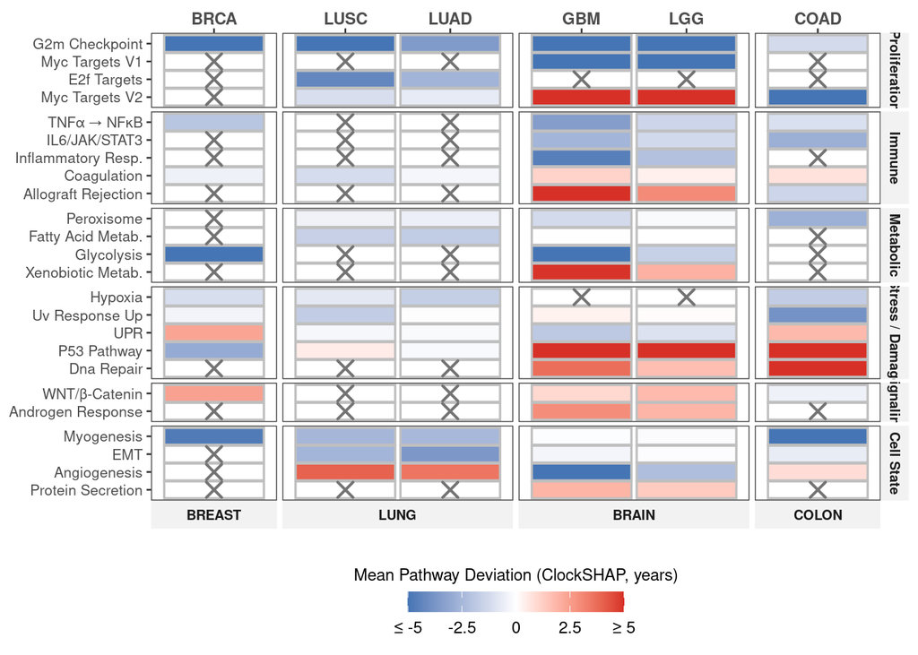

```r
p_fig4D
```

```r
out_file <- file.path(out_dir, "CrossCancer_Recurrent_Pathway_Overview.pdf")

ggsave(
  filename = out_file,
  plot = p_fig4D,
  width = 4.25,
  height = 7.5,
  units = "in"
)

message("Saved: ", out_file)
```

## Full pathway deviation overview

This version drops the cross-cancer recurrence requirement and shows all pathways whose mean ClockSHAP deviation contribution exceeds 1 year in magnitude in at least one cancer. Visualization choices match the recurrent pathway heatmap above (category facets, tissue grouping at bottom, grey X for non-retained pathways, ±5 year color cap, within-category ordering by direction prevalence and recurrence). Readers can use this panel to inspect single-cancer pathway signals that the recurrence filter excludes.

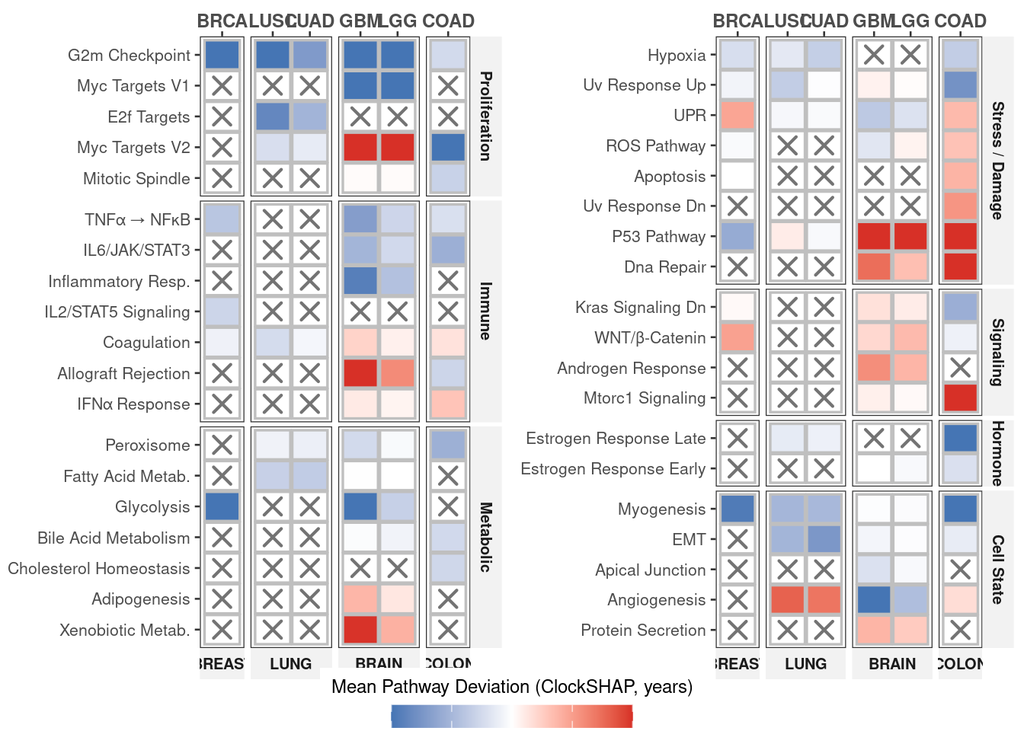

```r
# ---- supplement-specific tuning knobs ----
fig4DSupp_min_recurrence <- 1L    # any single cancer clearing the cutoff
fig4DSupp_min_abs_dev    <- 1.0

# ---- inclusion: |deviation| >= cutoff in at least 1 cancer ----
fig4DSupp_keep_tbl <- fig4D_dev_all_tbl %>%
  filter(
    is.finite(deviation_value),
    abs(deviation_value) >= fig4DSupp_min_abs_dev
  ) %>%
  group_by(pathway) %>%
  summarise(
    n_recurrent = dplyr::n_distinct(cancertype),
    max_abs_dev = max(abs(deviation_value), na.rm = TRUE),
    .groups = "drop"
  ) %>%
  filter(n_recurrent >= fig4DSupp_min_recurrence) %>%
  mutate(Category = assign_pathway_category(pathway))

fig4DSupp_path_keep <- fig4DSupp_keep_tbl$pathway

# ---- display category merging: same singleton-merge logic as main panel ----
fig4DSupp_cat_count_tbl <- fig4DSupp_keep_tbl %>%
  count(Category, name = "n_path_cat") %>%
  mutate(
    Category = factor(Category, levels = fig4D_base_category_levels)
  ) %>%
  arrange(n_path_cat, Category) %>%
  mutate(Category = as.character(Category))

fig4DSupp_display_groups <- list()
i <- 1L
g <- 1L

while (i <= nrow(fig4DSupp_cat_count_tbl)) {
  this_cat <- fig4DSupp_cat_count_tbl$Category[i]
  this_n   <- fig4DSupp_cat_count_tbl$n_path_cat[i]

  if (this_n == 1L && i < nrow(fig4DSupp_cat_count_tbl)) {
    group_cats <- c(this_cat, fig4DSupp_cat_count_tbl$Category[i + 1L])
    i <- i + 2L
  } else {
    group_cats <- this_cat
    i <- i + 1L
  }

  fig4DSupp_display_groups[[g]] <- tibble(
    Category = group_cats,
    DisplayCategory = paste(group_cats, collapse = " +\n")
  )
  g <- g + 1L
}

fig4DSupp_display_category_map <- bind_rows(fig4DSupp_display_groups)

fig4DSupp_keep_tbl <- fig4DSupp_keep_tbl %>%
  left_join(fig4DSupp_display_category_map, by = "Category")

fig4DSupp_display_category_levels <- fig4DSupp_display_category_map %>%
  mutate(
    Category = factor(Category, levels = fig4D_base_category_levels),
    display_priority = dplyr::case_when(
      Category == "Proliferation" ~ 1L,
      Category == "Immune" ~ 2L,
      Category == "Metabolic" ~ 3L,
      TRUE ~ 100L + as.integer(Category)
    )
  ) %>%
  group_by(DisplayCategory) %>%
  summarise(
    display_priority = min(display_priority),
    .groups = "drop"
  ) %>%
  arrange(display_priority, DisplayCategory) %>%
  pull(DisplayCategory)

# ---- build long table ----
fig4DSupp_plot_tbl <- fig4D_dev_all_tbl %>%
  filter(pathway %in% fig4DSupp_path_keep) %>%
  transmute(
    cancertype,
    pathway,
    value = deviation_value
  ) %>%
  left_join(fig4DSupp_keep_tbl, by = "pathway") %>%
  mutate(
    cancertype = factor(cancertype, levels = fig4D_cancer_order)
  )

# ---- within-category ordering: same logic as main panel ----
fig4DSupp_path_order <- fig4DSupp_plot_tbl %>%
  group_by(Category, pathway) %>%
  summarise(
    n_pos = sum(value > 0, na.rm = TRUE),
    n_neg = sum(value < 0, na.rm = TRUE),
    direction_score     = n_pos - n_neg,
    total_retention     = n_pos + n_neg,
    mean_across_cancers = mean(value, na.rm = TRUE),
    .groups = "drop"
  ) %>%
  group_by(Category) %>%
  arrange(direction_score, desc(total_retention), mean_across_cancers,
          .by_group = TRUE) %>%
  ungroup() %>%
  pull(pathway)

# ---- complete + retention join + factor cleanup ----
fig4DSupp_plot_tbl <- fig4DSupp_plot_tbl %>%
  select(cancertype, pathway, value) %>%
  mutate(pathway = factor(pathway, levels = fig4DSupp_path_order)) %>%
  tidyr::complete(
    cancertype,
    pathway,
    fill = list(value = 0)
  ) %>%
  left_join(
    fig4DSupp_keep_tbl %>%
      select(pathway, Category, DisplayCategory) %>%
      distinct() %>%
      mutate(pathway = factor(pathway, levels = fig4DSupp_path_order)),
    by = "pathway"
  ) %>%
  left_join(
    fig4D_retention_tbl %>%
      mutate(
        cancertype = factor(cancertype, levels = fig4D_cancer_order),
        pathway    = factor(pathway,    levels = fig4DSupp_path_order)
      ),
    by = c("cancertype", "pathway")
  ) %>%
  mutate(
    Category = factor(Category, levels = fig4D_base_category_levels),
    DisplayCategory = factor(DisplayCategory, levels = fig4DSupp_display_category_levels),
    Tissue = factor(
      unname(fig4D_tissue_map[as.character(cancertype)]),
      levels = fig4D_tissue_levels
    ),
    retained = ifelse(is.na(retained), FALSE, retained),
    pathway = factor(as.character(pathway), levels = fig4DSupp_path_order)
  )

# ---- split DisplayCategory levels into left/right halves ----
# First 3 categories on the left, remaining categories on the right.
fig4DSupp_split <- 3L
fig4DSupp_left_cats  <- head(fig4DSupp_display_category_levels, fig4DSupp_split)
fig4DSupp_right_cats <- tail(fig4DSupp_display_category_levels,
                             length(fig4DSupp_display_category_levels) - fig4DSupp_split)

# Shared plot builder: same styling for both halves, with optional legend.
build_fig4DSupp_half <- function(plot_tbl, keep_cats, include_legend = FALSE) {
  p <- ggplot(
    plot_tbl %>% filter(DisplayCategory %in% keep_cats) %>%
      mutate(DisplayCategory = droplevels(factor(
        DisplayCategory,
        levels = keep_cats
      ))),
    aes(x = cancertype, y = pathway, fill = value)
  ) +
    geom_tile(
      colour = "grey75",
      linewidth = 0.6,
      width = 0.95,
      height = 0.95
    ) +
    geom_point(
      data = function(d) d %>% filter(!retained),
      shape = 4,
      size = 3.2,
      colour = "grey45",
      stroke = 1.1
    ) +
    scale_fill_gradient2(
      low = "#4575b4",
      mid = "white",
      high = "#d73027",
      midpoint = 0,
      limits = c(-fig4D_scale_cap, fig4D_scale_cap),
      oob = scales::squish,
      breaks = c(-fig4D_scale_cap, -fig4D_scale_cap / 2, 0,
                 fig4D_scale_cap / 2, fig4D_scale_cap),
      labels = c(sprintf("\u2264 %g", -fig4D_scale_cap),
                 sprintf("%g", -fig4D_scale_cap / 2),
                 "0",
                 sprintf("%g", fig4D_scale_cap / 2),
                 sprintf("\u2265 %g", fig4D_scale_cap)),
      name = "Mean Pathway Deviation (ClockSHAP, years)",
      guide = guide_colorbar(
        direction = "horizontal",
        barwidth = unit(4.2, "cm"),
        barheight = unit(0.4, "cm"),
        title.position = "top",
        title.hjust = 0.5
      )
    ) +
    facet_grid(
      DisplayCategory ~ Tissue,
      scales = "free",
      space = "free",
      switch = "x"
    ) +
    scale_x_discrete(position = "top") +
    scale_y_discrete(limits = rev) +
    labs(x = NULL, y = NULL) +
    theme_bw(base_size = 10) +
    theme(
      strip.background = element_rect(fill = "grey95", colour = NA),
      strip.placement = "outside",
      strip.text.y.right = element_text(face = "bold", size = 7.5, lineheight = 0.9),
      strip.text.x.bottom = element_text(face = "bold", size = 7.5),
      axis.text.x = element_text(size = 9, face = "bold"),
      axis.text.y = element_text(size = 8),
      panel.grid = element_blank(),
      panel.spacing.x = unit(3, "pt"),
      panel.spacing.y = unit(2, "pt"),
      legend.position = if (include_legend) "bottom" else "none",
      legend.box.margin = margin(t = 6),
      legend.text = element_text(size = 9),
      legend.title = element_text(size = 9)
    )

  p
}

p_fig4DSupp_left  <- build_fig4DSupp_half(fig4DSupp_plot_tbl, fig4DSupp_left_cats,
                                          include_legend = FALSE)
p_fig4DSupp_right <- build_fig4DSupp_half(fig4DSupp_plot_tbl, fig4DSupp_right_cats,
                                          include_legend = FALSE)

# ---- shared legend, pulled from a separately-built version with legend on ----
fig4DSupp_legend <- cowplot::get_legend(
  build_fig4DSupp_half(fig4DSupp_plot_tbl, fig4DSupp_left_cats,
                       include_legend = TRUE)
)

# ---- side-by-side composition with shared legend below ----
p_fig4DSupp <- cowplot::plot_grid(
  cowplot::plot_grid(
    p_fig4DSupp_left,
    p_fig4DSupp_right,
    ncol = 2,
    align = "h",
    axis = "tb"
  ),
  fig4DSupp_legend,
  ncol = 1,
  rel_heights = c(1, 0.06)
)

p_fig4DSupp
```

```r
out_file <- file.path(out_dir, "CrossCancer_Pathway_Deviation_Full.pdf")

# Two-column layout: roughly twice as wide, roughly half as tall as the
# single-column version.
ggsave(
  filename = out_file,
  plot = p_fig4DSupp,
  width  = 8.5,
  height = 6.5,
  units = "in"
)

message("Saved: ", out_file)
```